# SOC/CSSS/CSDE 533 Homework 4

Sarah Kilpatrick

2025-03-06

# Problem 1: Cohort Component Projection Method - 20 points

*Essential Demographic Methods* **Chapter 7, Problem 5.**

**The matrix** $A$ shown below is a Leslie matrix for projecting the female population of Argentina. There are three age groups, each 18 years wide. The starting population for 1992 includes 3.9 million girls aged 0 to 18, 3.3 million women aged 18 to 36, and 2.8 million women aged 36 to 54.

$$\begin{equation*}
A = \left[ \begin{array}{ccc} 0.551 & 0.556 & 0.037 \\
0.962 & 0 & 0 \\
0 & 0.909 & 0 \\ \end{array}\right]
\end{equation*}$$

## (a) 5 points

**1. How long is the interval of time covered by a single projection step?**

18 years because each age group is 18 years wide.

**2. Describe the interpretation of the** $a_{12} = 0.962$ element of the Leslie matrix in words.

0.962 is the survival rate for group aged 0 to 18. The subdiagonal formed by 0.962 and 0.909 represents the percentage of individuals in that row/column’s age group that survive to the next age group.

**3. Describe the interpretation of the** $a_{11} = 0.551$ element of the Leslie matrix in words.

0.551 is the average number of female offspring born to a female individual per 18-year timestep in the 0-18 age group. The first row represents the fertility.

## (b) 5 points

**What is the total population of women up to age 54 after one projection step?**

```r
starting_argentina_fpop = c(3900000, 3300000, 2800000)

argentina_leslie = matrix(
  c(0.551, 0.556, 0.037, 0.962, 0, 0, 0, 0.909, 0),
  nrow = 3, ncol = 3,
  byrow = TRUE
)

argentina_fpop_projection1 = argentina_leslie %*% starting_argentina_fpop
cat(argentina_fpop_projection1, "\n", "\n")
```

```
## 4087300 3751800 2999700
##
```

```r
# total_population_up_to_54 = sum(onestep_argentina_fpop)

cat("The total population of women up to age 54 after one projection step is", sum(argentina_fpop_projection1))
```

```
## The total population of women up to age 54 after one projection step is 10838800
```

This is 18 years later. There will be nearly 11 million women up to age 54.

## (c) 5 points

**What is the total population of women up to age 54 after three projection steps? To what year would this total apply?**

```r
argentina_fpop_projection3 = argentina_leslie %*% argentina_leslie %*% argentina_leslie %*% starting_argentina_fpop

cat("The total population of women up to age 54 after three projection steps is", sum(argentina_fpop_projection3))
```

```
## The total population of women up to age 54 after three projection steps is 12618015
```

This is:
$$18*3 = \text{54 years after
1992}$$
which is the year $2046$.

## (d) 5 points

**At what rate would the population of Argentina be growing according to this projection over three projection steps?**

**This answer uses code from SOC/CSSS/CSDE 533 HW #1 provided by Jess Godwin.**

```r
projected_years <- c(2010, 2046)
population_B <- c(sum(argentina_fpop_projection1), sum(argentina_fpop_projection3))

population_data <- data.frame(projected_years, population_B)

population_data <- population_data %>%
  mutate(growth_rate = log( population_B / lag(population_B) ) / ( projected_years - lag(projected_years) ) )

population_data %>%
  filter(!is.na(growth_rate)) %>%
  mutate(Period = "2010-2046") %>%
  select(Period, growth_rate) %>%
  kbl(., digits = c(0, 4),
      row.names = FALSE,
      caption = paste0("Argentina's Female population growth rate between the first and third step population projection under the assumption of exponential growth.")) %>%
  kable_styling(position = "center", full_width = FALSE)
```

Argentina’s Female population growth rate between the first and third step population projection under the assumption of exponential growth.

| Period | growth_rate |
| --- | --- |
| 2010-2046 | 0.0042 |

# Problem 2: Computing a Leslie Matrix - 30 points

**We will use [Human Mortality Database](https://www.mortality.org/) and [Human Fertility Database](https://www.humanfertility.org/Home/Index) data for this problem. Select a country and 5-year period from whose mortality and fertility data you will create a Leslie matrix that ignores migration.**

I choose Ireland in the year 2000. This will be a closed, Female-only population. We assume it is stationary.

## (a) 5 points

**What dataset is necessary to calculate the non-zero elements of every row of the Leslie matrix besides the first? What dataset is also necessary to calculate the elements of row 1 of the Leslie matrix? Is there any other information you need to complete the first row? If so, what?**

We can use annual death rates data for the year 2000 instead of estimating age-specific mortality rates the long way, this will help us get the probability of survival for each set of age groups.

We also need age-specific fertility rates for the year 2000, which can be directly downloaded, rather than calculated by hand from birth counts and population; these data are also in annual 1x1 format.

Lastly, we need the population counts for Ireland in 200-2004.

If needed, we can assume as in HW #3, from the Essential Demographic Methods textbook, that the default fraction of Females at birth is 0.4886, that is, $SRB = \frac{1}{1+0.4886}$

**This answer uses code from HW #3 to read and clean the HMD and HFD data from rich text to dataframes.**

Important note: all of the ASFRs for the age group 12 and under, and the age group 55 and up, for all five years 2000-2004 are all = 0.

Initial Joined Data for female individuals in Ireland, Year 2000

| Year | Age | Female Population | Male Population | Total Population | Age-Specific Fertility Rate (Total) | Female nmx | Female nqx | Female nax | Female nlx | Female ndx | Female nLx | Female nTx | Female nex |
| --- | --- | --- | --- | --- | --- | --- | --- | --- | --- | --- | --- | --- | --- |
| 2000 | 0 | 25971.25 | 27576.62 | 53547.87 | 0.00000 | 0.00516 | 0.00513 | 0.14 | 100000 | 513 | 99558 | 7919284 | 79.19 |
| 2000 | 1 | 26092.90 | 27703.48 | 53796.38 | 0.00000 | 0.00015 | 0.00015 | 0.50 | 99487 | 15 | 99479 | 7819726 | 78.60 |
| 2000 | 2 | 26101.12 | 27592.58 | 53693.70 | 0.00000 | 0.00019 | 0.00019 | 0.50 | 99472 | 19 | 99462 | 7720247 | 77.61 |
| 2000 | 3 | 25310.03 | 27096.73 | 52406.76 | 0.00000 | 0.00008 | 0.00008 | 0.50 | 99453 | 8 | 99449 | 7620785 | 76.63 |
| 2000 | 4 | 24567.55 | 26311.26 | 50878.81 | 0.00000 | 0.00020 | 0.00020 | 0.50 | 99445 | 20 | 99435 | 7521336 | 75.63 |
| 2000 | 5 | 24852.81 | 26403.25 | 51256.06 | 0.00000 | 0.00020 | 0.00020 | 0.50 | 99425 | 20 | 99415 | 7421901 | 74.65 |
| 2000 | 6 | 25122.52 | 26484.64 | 51607.16 | 0.00000 | 0.00012 | 0.00012 | 0.50 | 99405 | 12 | 99399 | 7322485 | 73.66 |
| 2000 | 7 | 26203.66 | 27360.77 | 53564.43 | 0.00000 | 0.00016 | 0.00016 | 0.50 | 99393 | 15 | 99386 | 7223086 | 72.67 |
| 2000 | 8 | 27033.27 | 27763.32 | 54796.59 | 0.00000 | 0.00011 | 0.00011 | 0.50 | 99378 | 11 | 99372 | 7123700 | 71.68 |
| 2000 | 9 | 27385.03 | 29205.16 | 56590.19 | 0.00000 | 0.00015 | 0.00015 | 0.50 | 99367 | 15 | 99359 | 7024328 | 70.69 |
| 2000 | 10 | 27540.34 | 28904.90 | 56445.24 | 0.00000 | 0.00015 | 0.00015 | 0.50 | 99352 | 14 | 99345 | 6924969 | 69.70 |
| 2000 | 11 | 27843.07 | 29032.53 | 56875.60 | 0.00000 | 0.00014 | 0.00014 | 0.50 | 99338 | 14 | 99330 | 6825624 | 68.71 |
| 2000 | 12 | 28782.23 | 29986.29 | 58768.52 | 0.00000 | 0.00007 | 0.00007 | 0.50 | 99323 | 7 | 99320 | 6726293 | 67.72 |
| 2000 | 13 | 29774.42 | 31665.03 | 61439.45 | 0.00000 | 0.00014 | 0.00014 | 0.50 | 99316 | 14 | 99310 | 6626973 | 66.73 |
| 2000 | 14 | 30565.08 | 32512.79 | 63077.87 | 0.00004 | 0.00026 | 0.00026 | 0.50 | 99303 | 26 | 99290 | 6527664 | 65.73 |
| 2000 | 15 | 30686.64 | 32447.44 | 63134.08 | 0.00108 | 0.00036 | 0.00036 | 0.50 | 99277 | 36 | 99259 | 6428374 | 64.75 |
| 2000 | 16 | 32072.60 | 33453.92 | 65526.52 | 0.00386 | 0.00029 | 0.00029 | 0.50 | 99241 | 29 | 99227 | 6329116 | 63.78 |
| 2000 | 17 | 33413.93 | 35484.37 | 68898.30 | 0.01073 | 0.00049 | 0.00049 | 0.50 | 99212 | 48 | 99188 | 6229889 | 62.79 |
| 2000 | 18 | 32932.52 | 34669.27 | 67601.79 | 0.02236 | 0.00025 | 0.00025 | 0.50 | 99164 | 24 | 99152 | 6130701 | 61.82 |
| 2000 | 19 | 32605.19 | 34236.58 | 66841.77 | 0.03670 | 0.00052 | 0.00052 | 0.50 | 99140 | 52 | 99114 | 6031549 | 60.84 |
| 2000 | 20 | 33276.77 | 33577.37 | 66854.14 | 0.04523 | 0.00045 | 0.00045 | 0.50 | 99088 | 44 | 99065 | 5932436 | 59.87 |
| 2000 | 21 | 31857.70 | 31766.05 | 63623.75 | 0.04701 | 0.00034 | 0.00034 | 0.50 | 99043 | 34 | 99027 | 5833370 | 58.90 |
| 2000 | 22 | 29371.82 | 30278.90 | 59650.72 | 0.04941 | 0.00052 | 0.00052 | 0.50 | 99010 | 52 | 98984 | 5734344 | 57.92 |
| 2000 | 23 | 28454.00 | 30398.44 | 58852.44 | 0.05377 | 0.00021 | 0.00021 | 0.50 | 98958 | 21 | 98947 | 5635360 | 56.95 |
| 2000 | 24 | 30307.18 | 30293.99 | 60601.17 | 0.05594 | 0.00050 | 0.00050 | 0.50 | 98937 | 49 | 98912 | 5536412 | 55.96 |
| 2000 | 25 | 28792.22 | 30426.27 | 59218.49 | 0.05986 | 0.00030 | 0.00030 | 0.50 | 98888 | 30 | 98873 | 5437500 | 54.99 |
| 2000 | 26 | 27593.07 | 28383.95 | 55977.02 | 0.07333 | 0.00032 | 0.00032 | 0.50 | 98858 | 32 | 98842 | 5338627 | 54.00 |
| 2000 | 27 | 28953.56 | 28520.88 | 57474.44 | 0.08769 | 0.00051 | 0.00051 | 0.50 | 98826 | 50 | 98800 | 5239786 | 53.02 |
| 2000 | 28 | 28651.30 | 28542.64 | 57193.94 | 0.10143 | 0.00020 | 0.00020 | 0.50 | 98775 | 20 | 98765 | 5140985 | 52.05 |
| 2000 | 29 | 28175.32 | 28555.79 | 56731.11 | 0.11613 | 0.00035 | 0.00035 | 0.50 | 98755 | 34 | 98738 | 5042220 | 51.06 |

[output cut: 81 more lines]

## (b) 5 points

**Calculate the non-zero elements of every row of the Leslie matrix except the first. Show your code and display your calculations in some way.**

I am choosing to project forward the year 2000.

We can calculate the survivorship proportions for each age group as follows:

$$\frac{_{n}L_{x}}{_{n}L_{x-n}}$$
For a stationary population, $_{n}L_{x}$ is the number of people alive aged $[x, x+n)$ at the selected year. For our purposes, we will use Lx values from the life table. These values will form the diagonal elements in the Leslie matrix, excluding the first row (the fertility row)

the early-age age-group survivorship can be done with the following equation, which will fill in the first element of the survivorship column:

$$_{n}N_{0}^F(t + n) =
\frac{_{n}L_{0}}{l_{0}} \times _{n}B_{x}[t, t+n)$$

```r
ireland_data_2000$survivorship = NA

          # first row has no preceding age group
for (i in 2:nrow(ireland_data_2000)) {
    #(current age group's Lx) / (previous age group's Lx)
    ireland_data_2000$survivorship[i] = ireland_data_2000$Female_Lx[i] / ireland_data_2000$Female_Lx[i - 1]
  }

ireland_data_2000$survivorship[1] = ireland_data_2000$Female_Lx[1] / ireland_data_2000$Female_lx[1]

# hard-code before we combine age group 109 and 110+
# since no one survives open interval, must put T_{x+n}/T_{x} instead
ireland_data_2000$survivorship[nrow(ireland_data_2000)] = 0

show_survivorship_ireland_data_2000 = ireland_data_2000 %>%
  select(Age, survivorship)

kable(show_survivorship_ireland_data_2000,
      col.names = c("Age", "Survivorship"),
      caption = "Sanity Checking Survivorship") %>%
  kable_styling(font_size = 15,
                bootstrap_options = c("striped", "condensed")) %>%
  scroll_box(width = "300px", height = "600px")
```

Sanity Checking Survivorship

| Age | Survivorship |
| --- | --- |
| 0 | 0.9955800 |
| 1 | 0.9992065 |
| 2 | 0.9998291 |
| 3 | 0.9998693 |
| 4 | 0.9998592 |
| 5 | 0.9997989 |
| 6 | 0.9998391 |
| 7 | 0.9998692 |
| 8 | 0.9998591 |
| 9 | 0.9998692 |
| 10 | 0.9998591 |
| 11 | 0.9998490 |
| 12 | 0.9998993 |
| 13 | 0.9998993 |
| 14 | 0.9997986 |
| 15 | 0.9996878 |
| 16 | 0.9996776 |
| 17 | 0.9996070 |
| 18 | 0.9996371 |
| 19 | 0.9996168 |
| 20 | 0.9995056 |
| 21 | 0.9996164 |
| 22 | 0.9995658 |
| 23 | 0.9996262 |
| 24 | 0.9996463 |
| 25 | 0.9996057 |
| 26 | 0.9996865 |
| 27 | 0.9995751 |
| 28 | 0.9996457 |
| 29 | 0.9997266 |

[output cut: 81 more lines]

```r
ireland_data_2000$Female_ASFR = NA

for (i in 1:nrow(ireland_data_2000)) {
      ireland_data_2000$Female_ASFR[i] = ireland_data_2000$ASFR[i]*(1/(1+1.05))
  }

# remove unnecessary columns for brevity
ireland_data_2000F = ireland_data_2000 %>%
  select(-Year, -Male_Pop, -Total_Pop, -ASFR, -Female_ax, Female_dx, -Female_ex)

ireland_data_2000F$survivorship[nrow(ireland_data_2000F)] = 0
```

We can also clean up the Ireland data and create a new row that collapses the final few age groups, so that the final line has observed fertility and death data rather than 0’s. This means the “109” age group is really the “109 and 110+” age group:

```r
# last two rows (109 and 110+ age group)
last_two_rows = tail(ireland_data_2000F, 2)

# Sum the values for numerical columns
summed_row = last_two_rows %>%
  summarise(
    Age = "109",
    Female_Pop = sum(Female_Pop, na.rm = TRUE),
    Female_mx = sum(Female_Pop, na.rm = TRUE),
    Female_qx = sum(Female_qx, na.rm = TRUE),
    Female_lx = sum(Female_lx, na.rm = TRUE),
    Female_dx = sum(Female_lx, na.rm = TRUE),
    Female_Lx = sum(Female_Lx, na.rm = TRUE),
    Female_Tx = sum(Female_Tx, na.rm = TRUE),
    survivorship = sum(survivorship, na.rm = TRUE),
    Female_ASFR = sum(Female_ASFR, na.rm = TRUE)

  )

ireland_data_2000F = ireland_data_2000F %>%
  slice(1:(n() - 2)) %>%
  bind_rows(summed_row)
```

And create the leslie matrix:

```r
# leslie matrix dimensions: same number of rows and columns as there are age groups
num_age_groups = length(unique(ireland_data_2000F$Age))

ireland_leslie_matrix = matrix(NA, nrow = num_age_groups, ncol = num_age_groups)

survivorship_values = ireland_data_2000F$survivorship[1:num_age_groups]

# Place the survivorship values on the subdiagonal (starting from row 2, column 1)
for (i in 1:length(survivorship_values) - 1) {
  ireland_leslie_matrix[i + 1, i] <- survivorship_values[i]
}

ireland_leslie_matrix[is.na(ireland_leslie_matrix)] = 0

top_5x5 <- ireland_leslie_matrix[1:5, 1:5]
print("First few rows and columns of the Leslie Matrix")
```

```
## [1] "First few rows and columns of the Leslie Matrix"
```

```r
print(top_5x5)
```

```
##         [,1]      [,2]      [,3]      [,4] [,5]
## [1,] 0.00000 0.0000000 0.0000000 0.0000000    0
## [2,] 0.99558 0.0000000 0.0000000 0.0000000    0
## [3,] 0.00000 0.9992065 0.0000000 0.0000000    0
## [4,] 0.00000 0.0000000 0.9998291 0.0000000    0
## [5,] 0.00000 0.0000000 0.0000000 0.9998693    0
```

The open interval (final age group) can be projected forwards by summing up the survivors to age x with the survivors above age x.

$$_{\infty}N_{x}^F(t+n) =
_{n}N_{x-n}^F(t) \times \frac{_{n}L_{x}}{_{n}L_{x - n}} +
_{\infty}N_{x}^F(t) \times \frac{T_{x + n}}{T_{x}}$$

Which in the lecture 11 leslie matrix powerpoint slide can be calculated as:

$$\frac{T_{x + n}}{T_{x}}$$

```r
penult_index = nrow(ireland_data_2000F) -1
final_index = nrow(ireland_data_2000F)

T_x_penult <- ireland_data_2000F$Female_Tx[penult_index]  # T_x
T_x_final <- ireland_data_2000F$Female_Tx[final_index]  # T_{x+n}

open_interval_scalar = T_x_final/T_x_penult

# Insert the computed value into the last row/last column of the Leslie matrix
ireland_leslie_matrix[final_index, ncol(ireland_leslie_matrix)] <- open_interval_scalar

tail_5x5 <- ireland_leslie_matrix[(nrow(ireland_leslie_matrix)-4):nrow(ireland_leslie_matrix),
                                  (ncol(ireland_leslie_matrix)-4):ncol(ireland_leslie_matrix)]
print("Final few rows and columns of the Leslie Matrix")
```

```
## [1] "Final few rows and columns of the Leslie Matrix"
```

```r
print(tail_5x5)
```

```
##           [,1]      [,2] [,3] [,4]      [,5]
## [1,] 0.0000000 0.0000000  0.0  0.0 0.0000000
## [2,] 0.5342466 0.0000000  0.0  0.0 0.0000000
## [3,] 0.0000000 0.5128205  0.0  0.0 0.0000000
## [4,] 0.0000000 0.0000000  0.5  0.0 0.0000000
## [5,] 0.0000000 0.0000000  0.0  0.5 0.6666667
```

## (c) 5 points

**Calculate the non-zero elements of the first row of the Leslie matrix. Show your code and display your calculations in some way.**

We can assume that any age group not recorded in the HFD (12 and under, 55 and over) has an ASFR = 0.

The births that fill in the first row of the leslie matrix can be calculated using this formula, the sum of two terms:

$$_{n}B_{x}[t, t+n) = (_{n}F_{x} \times n
\times \frac{_{n}N_{x}^F}{2}) + (_{n}F_{x} \times n \times
\frac{_{n}N_{x-n}^F \times
\frac{_{n}L_{x}}{_{n}L_{x-n}}}{2})$$

Where all $_{n}F_{x}$ values are those for Female births only. The $_{n}N_{x}$ values are set = 1 as the input vector will be acted upon by this portion of the leslie matrix, so there’s no need to duplicate the transformation.

```r
n = 1

ireland_data_2000F <- ireland_data_2000F %>%
   mutate(
    nLx_prev = lag(Female_Lx, default = NA),   # nL_{(x - n)}
    nFx_prev = lag(Female_Pop, default = NA), # nN_{(x - n)}^F
    term1 = Female_ASFR * n * (1/ (2)),
    term2 = Female_ASFR * n * ((1 * (Female_Lx / nLx_prev)) / (2)),
    # gets rid of NAs
    nBx = ifelse(is.na(nLx_prev) | is.na(nFx_prev), 0, (term1 + term2)*ireland_data_2000F$survivorship[1])
  )

ireland_data_2000F[is.na(ireland_data_2000F)] = 0
```

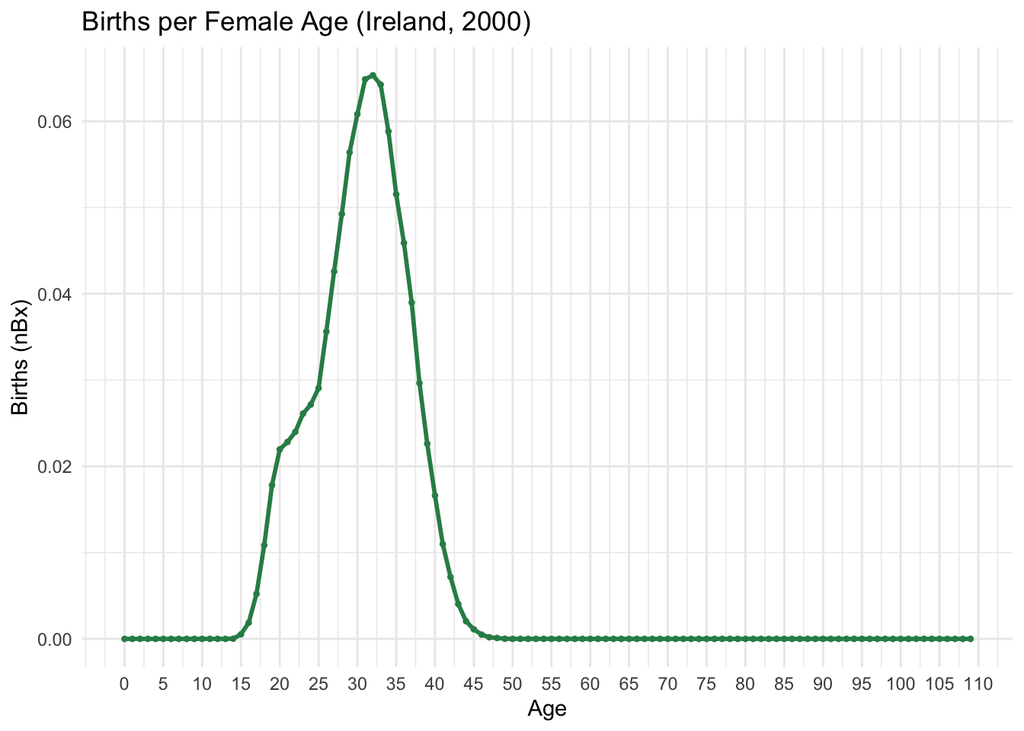

```r
fertility_row <- ireland_data_2000F$nBx
ireland_leslie_matrix[1, ] <- fertility_row

ggplot(ireland_data_2000F, aes(x = as.numeric(Age), y = nBx)) +
  geom_line(color = "seagreen", linewidth = 1) +
  geom_point(color = "seagreen", size = .85) +
  labs(
    title = "Births per Female Age (Ireland, 2000)",
    x = "Age",
    y = "Births (nBx)"
  ) +
  theme_minimal() +
  scale_x_continuous(breaks = seq(0, 110, by = 5))
```

## (d) 5 points

**What remaining dataset is necessary to implement the cohort component projection method?**

The population of Ireland in 2000, which we will transform linearly using the leslie matrix. This data is in the Female_Pop column, which has this distribution:

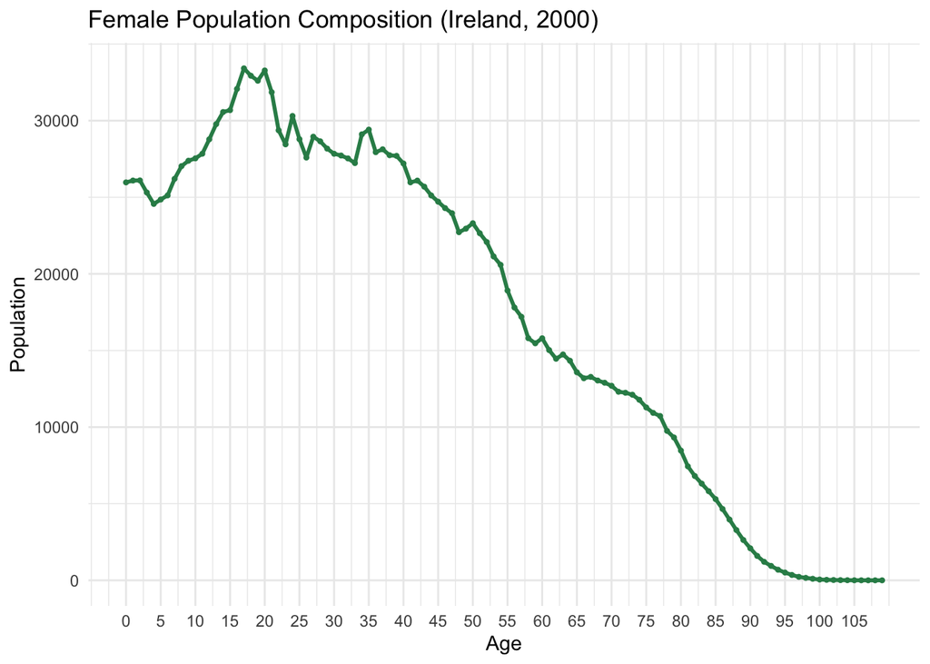

```r
ggplot(ireland_data_2000F, aes(x = as.numeric(Age), y = Female_Pop)) +
  geom_line(color = "seagreen", linewidth = 1) +
  geom_point(color = "seagreen", size = .85) +
  labs(
    title = "Female Population Composition (Ireland, 2000)",
    x = "Age",
    y = "Population"
  ) +
  theme_minimal() +
  scale_x_continuous(breaks = seq(0, 105, by = 5))
```

## (e) 5 points

**Create your full Leslie matrix and project forward your population in 5 and 25 years.**

In order to project forward 5 years and 25 years, we will need to transform the data 5 times and 25 times, rather than once and five times, if the data had been in 5x5 groups and intervals.

```r
project_population = function(matrix, input_data, years_list) {
  #must convert to matrix otherwise it throws an error
  n_vector <- as.matrix(input_data)
  num_age_groups <- nrow(matrix)

  if (length(n_vector) != num_age_groups) {
    stop("Population vector length must match the number of rows in the Leslie matrix.")
  }

  ireland_projection <- data.frame(Age = ireland_data_2000F$Age)

  for (years in years_list) {
    temp_vector <- n_vector
    for (i in 1:years) {
      temp_vector <- matrix %*% temp_vector
    }
    ireland_projection[[paste0("Projection_", years, "_years")]] <- as.numeric(temp_vector)
  }

  return(ireland_projection)
}

years_to_project = c(5, 25, 50, 100, 150, 200)
ireland_population_projections = project_population(ireland_leslie_matrix, ireland_data_2000F$Female_Pop, years_to_project)
```

## (f) 5 points

**Create two population pyramids with the present day age structure on the left side and the projected age structure on the right, i.e. one plot will have the 5-year projection on the right and the other will have the 25-year projection on the right. Hint: See the R Lab 4 materials if you have not made a population pyramid before.**

**This homework uses code from R Lab 3 to construct the population pyramid.**

```r
plot_ireland_2000 <- ireland_data_2000F %>%
  select(Age, Female_Pop) %>%
  mutate(Year = "2000") %>%
  mutate(Age = as.numeric(Age)) %>%
  mutate(Year = as.numeric(Year)) %>%
  mutate(Pop_plot = -Female_Pop/sum(Female_Pop))

plot_ireland_2005 <- ireland_population_projections %>%
  select(Age, Projection_5_years) %>%
  rename(Female_Pop = Projection_5_years) %>%
  mutate(Year = "2005") %>%
  mutate(Pop_plot = Female_Pop/sum(Female_Pop)) %>%
  mutate(Age = as.numeric(Age)) %>%
  mutate(Year = as.numeric(Year))

plot_ireland_2025 <- ireland_population_projections %>%
  select(Age, Projection_25_years) %>%
  rename(Female_Pop = Projection_25_years) %>%
  mutate(Year = "2025") %>%
  mutate(Pop_plot = Female_Pop/sum(Female_Pop)) %>%
  mutate(Age = as.numeric(Age)) %>%
  mutate(Year = as.numeric(Year))

plot1_data = bind_rows(plot_ireland_2000, plot_ireland_2005)
plot2_data = bind_rows(plot_ireland_2000, plot_ireland_2025)
```

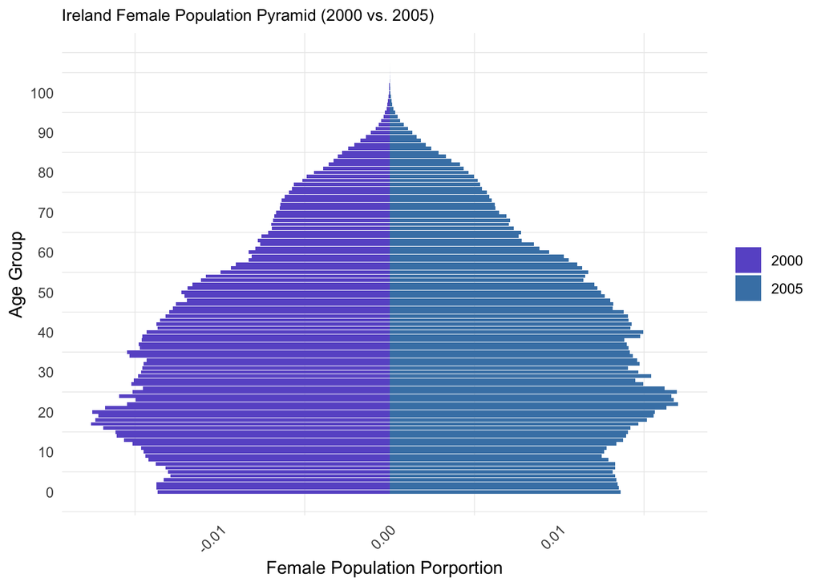

```r
# First Pyramid (2000 vs. 2005)
ggplot(plot1_data, aes(x = Age, y = Pop_plot, fill = as.factor(Year))) +
  geom_bar(stat = "identity") +
  scale_x_continuous(
    breaks = seq(0, max(plot1_data$Age), by = 10)
  ) +
  coord_flip() +  # Flip coordinates to make the bar plot horizontal
  theme_minimal() +
  theme(
    axis.text.x = element_text(angle = 45, hjust = 1),
    plot.title = element_text(size = 10),
    legend.title = element_blank(),
    panel.grid.major = element_blank()
  ) +
  labs(
    x = "Age Group", y = "Female Population Porportion",
    fill = "Year", title = paste("Ireland Female Population Pyramid (", 2000, " vs. ", 2005, ")", sep = "")
  ) +
  scale_fill_manual(values = c("2000" = "slateblue", "2005" = "steelblue"))
```

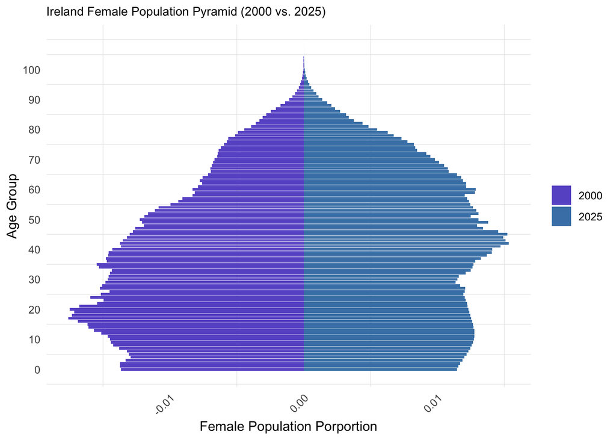

```r
# Second Pyramid (2000 vs 2025)
ggplot(plot2_data, aes(x = as.numeric(Age), y = Pop_plot, fill = as.factor(Year))) +
  geom_bar(stat = "identity") +
  scale_x_continuous(
    breaks = seq(0, max(plot2_data$Age), by = 10)
  ) +
  coord_flip() +
  theme_minimal() +
  theme(
    axis.text.x = element_text(angle = 45, hjust = 1),
    plot.title = element_text(size = 10),
    legend.title = element_blank(),
    panel.grid.major = element_blank()
  ) +
  labs(
    x = "Age Group", y = "Female Population Porportion",  # x is Age, y is Female Population proportion
    fill = "Year", title = paste("Ireland Female Population Pyramid (", 2000, " vs. ", 2025, ")", sep = "")
  ) +
  scale_fill_manual(values = c("2000" = "slateblue", "2025" = "steelblue"))
```

# Problem 3: Finding the Stable Equivalent Population – 30 points

**Using the same country and 5-year period you used in Problem 2, let’s project forward using the Leslie matrix until we see stability in the female age structure of the population.**

Concepts and formulas from [this resource](https://hanowell.github.io/uwsoc533a/stable-population-model.html) written by Ben Hanowell and [this resource](https://grodri.github.io/demography/stablepop) written by Germán Rodríguez were integral in drafting the following answers. No code from either website was implemented in this homework.

To do this problem we must assume the population is stationary.

## (a) 10 points

**Using the cohort component projection method, project forward the population from your starting 5-year period 50, 100, 150, and 200 years. Make figures like in Problem 2(f) for each of these projections. Comment on whether it appears the stable equivalent population implied by your chosen fertility and mortality rates has been reached.**

These pyramid plots are created normalizing the amount of each population with the Pop_proportion column, which helps in comparing the projections to one another.

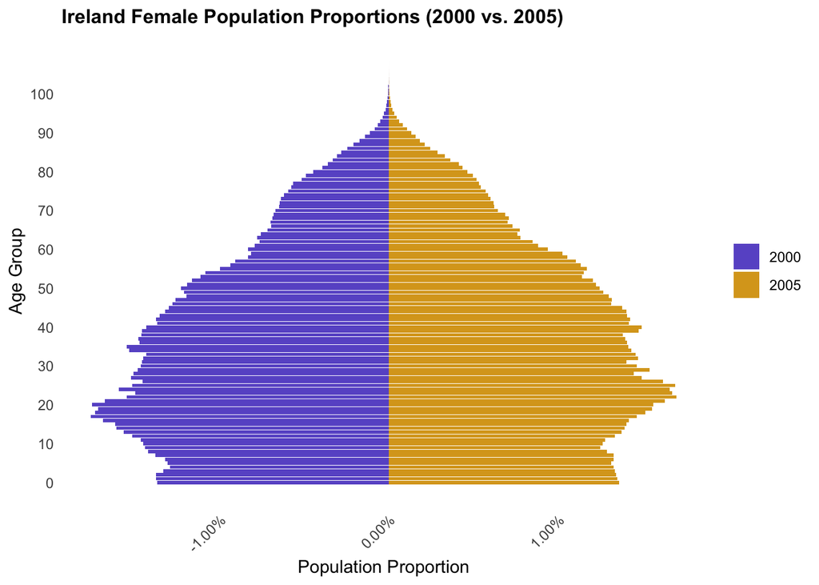

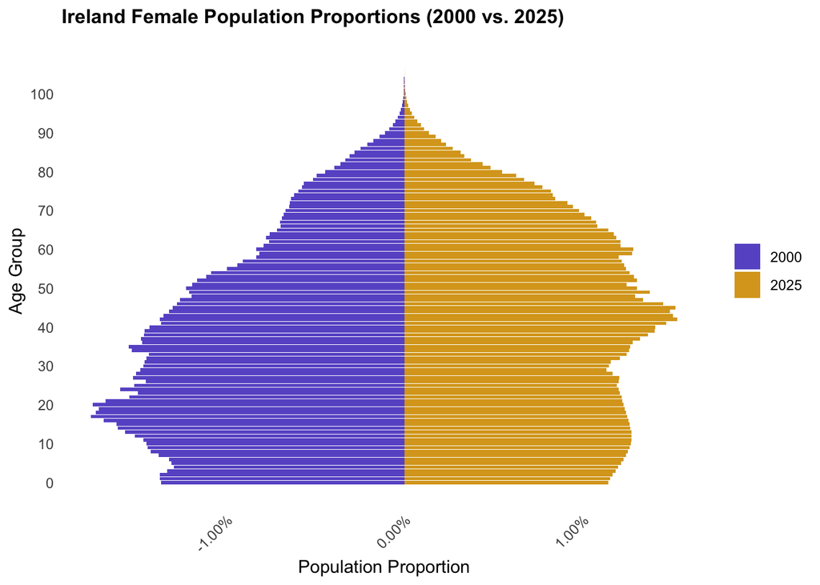

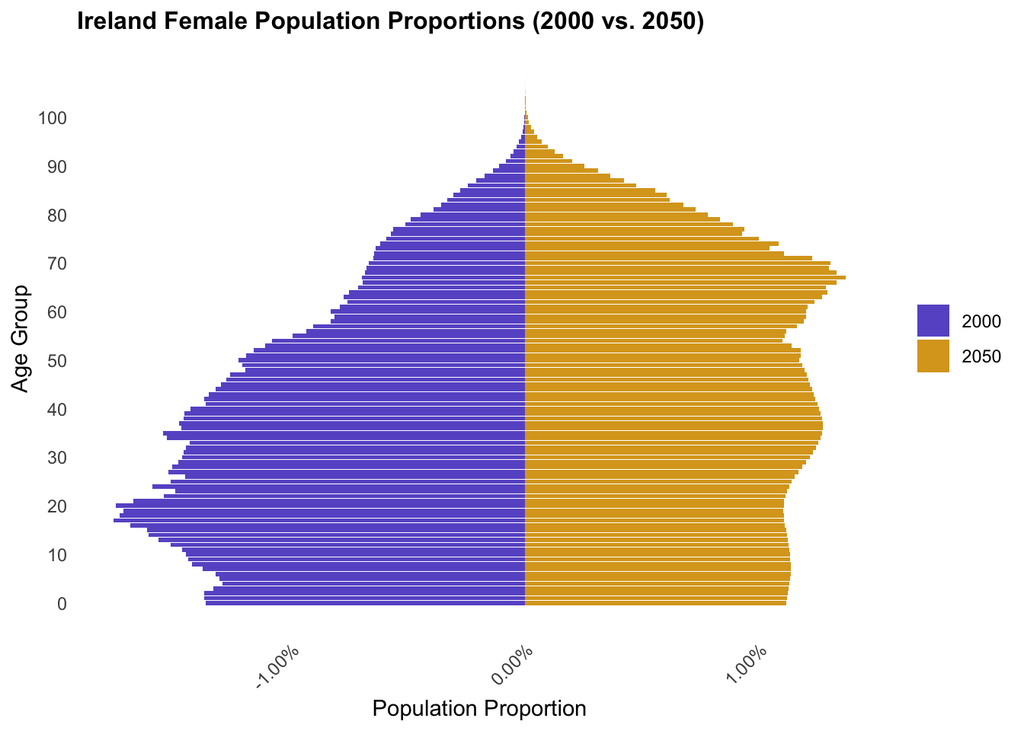

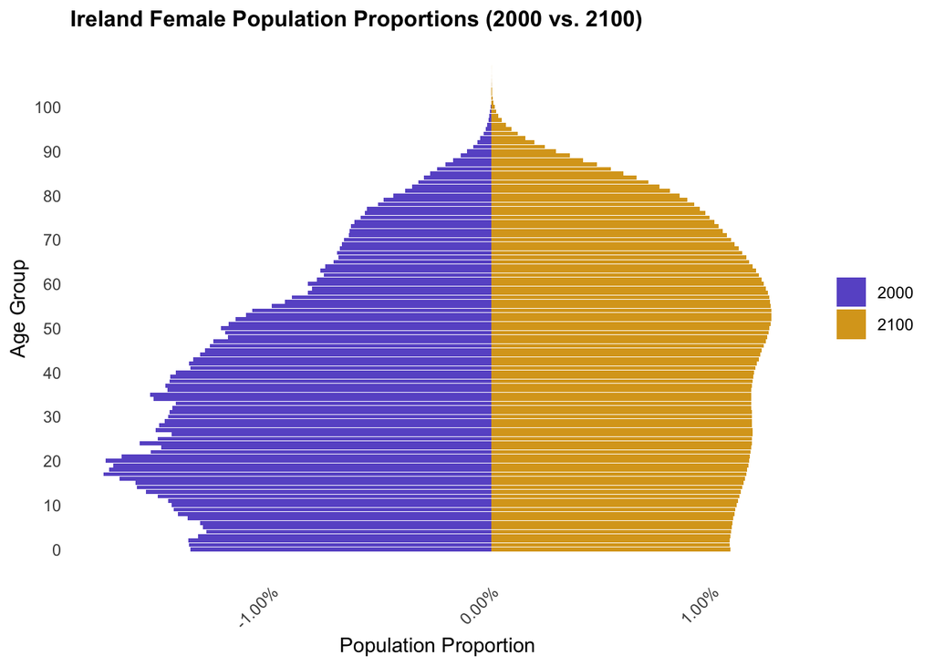

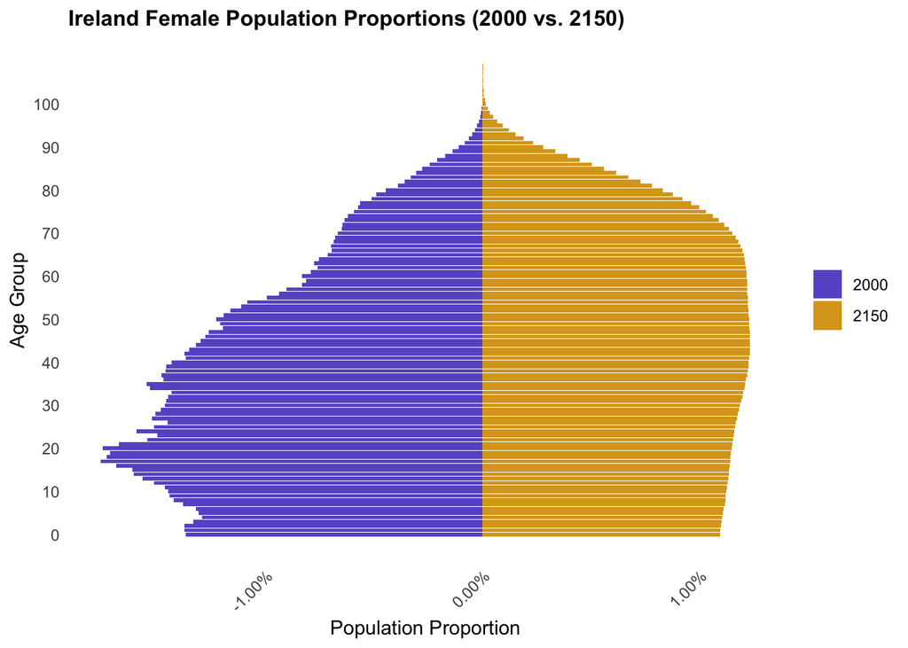

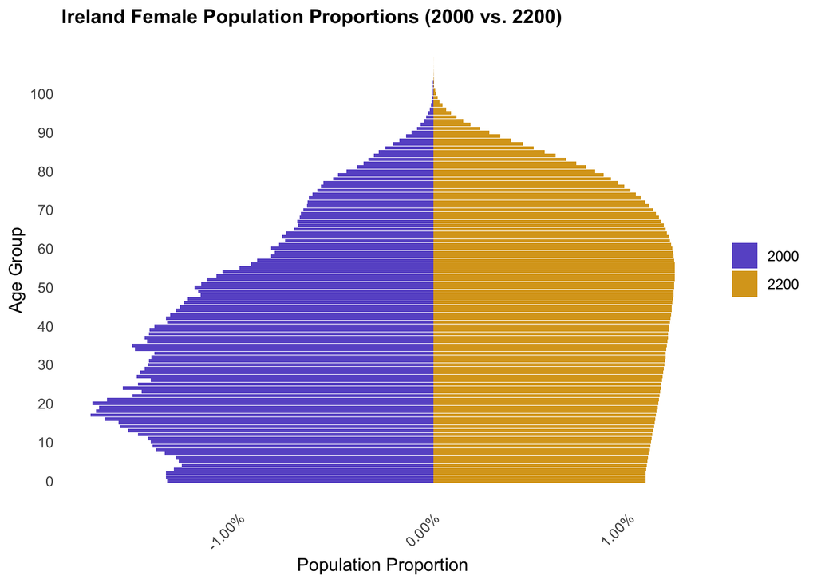

```r
preplot_process = function(base_data, projections, years_to_project) {
  #year 2000 data
  base_plot = base_data %>%
    select(Age, Female_Pop) %>%
    mutate(
      Year = 2000,
      Age = as.numeric(Age),
      Pop_plot = -Female_Pop,
      Pop_proportion = -Female_Pop / sum(Female_Pop)
    )

  process_projection = function(year) {
    year_col = paste0("Projection_", year, "_years")

    projections %>%
      select(Age, all_of(year_col)) %>%
      rename(Female_Pop = all_of(year_col)) %>%
      mutate(
        Year = as.numeric(2000 + year),
        Age = as.numeric(Age),
        Pop_plot = Female_Pop,
        Pop_proportion = Female_Pop / sum(Female_Pop)
      )
  }

  dataframes_for_plotting = lapply(years_to_project, function(year) {
    projected_data <- process_projection(year)
    bind_rows(base_plot, projected_data)  # Combine with 2000 data
  })

  names(dataframes_for_plotting) <- paste0("plot", years_to_project, "_data")

  return(dataframes_for_plotting)
}

dataframes_for_plotting = preplot_process(ireland_data_2000F, ireland_population_projections, years_to_project)

pyramid_plot = function(data, year1, year2) {
  ggplot(data, aes(x = Age, y = Pop_proportion, fill = as.factor(Year))) +
    geom_bar(stat = "identity", position = "identity") +
    scale_y_continuous(
      labels = scales::percent_format(accuracy = 0.01)  # Convert to percentage format
    ) +
    scale_x_continuous(
      breaks = seq(0, max(data$Age), by = 10)
    ) +
    coord_flip() +
    theme_minimal() +
    theme(
      axis.text.x = element_text(angle = 45, hjust = 1),
      plot.title = element_text(size = 12, face = "bold"),
      legend.title = element_blank(),
      panel.grid.major = element_blank(),
      panel.grid.minor = element_blank()
    ) +
    labs(
      x = "Age Group",
      y = "Population Proportion",
      fill = "Year",
      title = paste("Ireland Female Population Proportions (", year1, " vs. ", year2, ")", sep = "")
    ) +
    scale_fill_manual(values = setNames(c("slateblue", "goldenrod"), c("2000", as.character(year2))))
}

years_projected = c(2005, 2025, 2050, 2100, 2150, 2200)
pyramid_plots = list()

# This saves the plots to a list just in case
for (year in years_projected) {
  data_name = paste0("plot", year - 2000, "_data")
  pyramid_plots[[as.character(year)]] <- pyramid_plot(dataframes_for_plotting[[data_name]], 2000, year)
}

# print all plots
for (year in years_projected) {
  print(pyramid_plots[[as.character(year)]])
}
```